# WHAT THE CARD?!: A Visual Data Story

STATS 220 Semester One, 2026

Iris Arora

[figure not shown]

## The Digital Oracle: Logging the Golden Thread

Following our work in Project 2, Michael and I continued to log daily tarot pulls using the Golden Thread Tarot deck. This visual story explores the data behind the divinity. It looks past the mysticism to find patterns in our own interpretations and habits. Over the course of this collection period, we continued to record key categorical and numerical variables, including the card category (Major or Minor Arcana), the orientation (Upright or Reversed), the card number, and the short written interpretation of its meaning - a seamless continuation of project 2.

## Recurring Wisdom: Key Themes in Our Log

This chart shows that the generated interpretations often focus on linking specific themes to people. The high frequency of these words suggests that the pulls focus on building a consistent narrative rather than random generation.

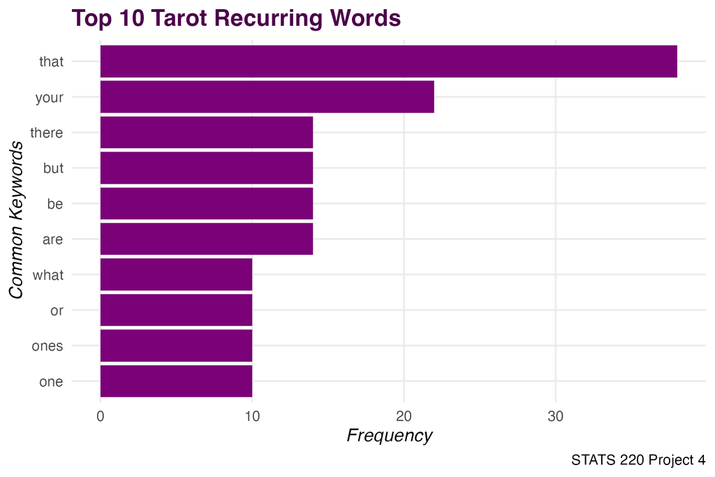

A bar chart showing the top 10 most frequent words in my tarot interpretations, with words like ‘that’ or ‘your’ appearing most often.

## The Hour of Insight: When the Cards Call

Does the time of day affect the type of card pulled? By using the `{lubridate}` package to extract the exact hour and day from Google Form timestamps, I mapped our pull habits.

By looking at the temporal distribution, I can see that Michael and I are most likely to consult the cards during specific “power hours.” The clustered points show a concentration of activity on weekdays, suggesting that our tarot practice is often an afternoon ritual or an evening reflection, rather than a random occurrence throughout the day, possibly due to our hectic timetables as science students.

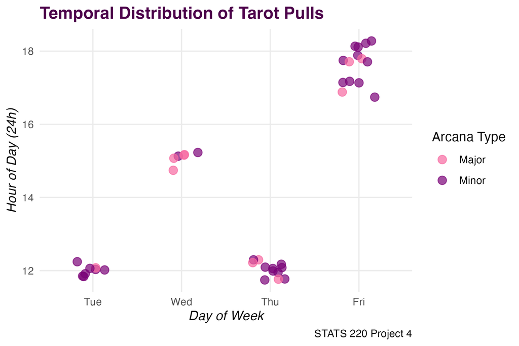

Jitter plot showing tarot draw times by day of week and hour (24h), colour-coded by Arcana category.

## Depth in Disruption: Does Orientation Matter?

Finally, I investigated whether a card being “reversed” prompts a deeper reflection. Statistical depth is measured here by the word count of each logged entry.

The distribution analysis suggests a subtle but meaningful connection between card orientation and interpretive depth. While the median word count is only slightly higher for reversed cards (about 42 words compared to roughly 40 for upright cards), the taller box for reversed draws reveals a greater spread in my reflections, indicating that reversed cards tend to evoke more varied interpretive responses.

The whiskers further extend this pattern; reversed cards reach the highest word counts (~60 words) and maintain a higher minimum threshold (~31 words) than upright cards, which peak lower (~52 words) and drop as low as 24 words. Rather than a strict rule, this suggests that reversed pulls carry a broader interpretive field, displaying complexity that upright cards do not always require. In this way, the reversed card follows tarot tradition, symbolising a broader symbolic space where meaning is not fixed but stretches and shifts, encouraging a more fluid fortune compared to the consistent rhythm of upright interpretations.

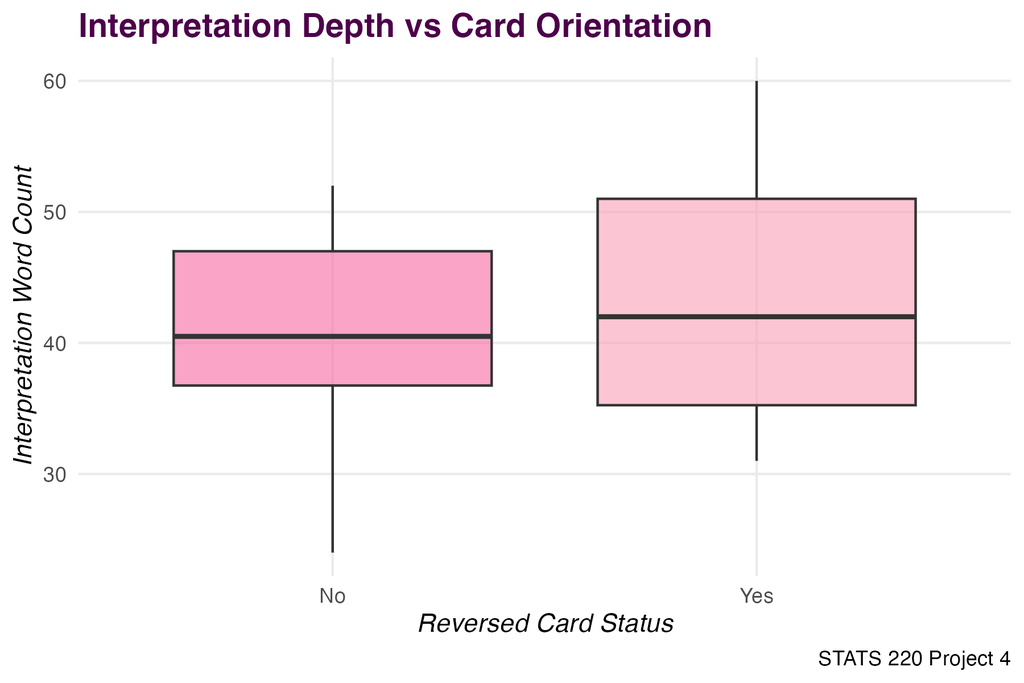

Boxplot comparing interpretation word counts for upright and reversed tarot cards.

## Closing the Loop

Through this analytical process and the broader study of data technologies, I have learned that these tools do more than organise numbers; they communicate meaningful patterns in everyday habits. By using `{stringr}` for text mining and `{lubridate}` for temporal analysis, this tarot practice was transformed into a structured visual narrative that is both statistically informative and personally reflective. These visualisations (encompassing recurring themes, ritualistic “power hours”, and the increased variability of reversed reflections) demonstrate how quantitative tools can surface the hidden rhythms and complexities of a personal practice.